# Gun Availability and Crime

JT McCrone

10/1/2014

The goal of this report is to explore data on gun availability crime rate as provided originally at [this student resource site](http://wps.aw.com/aw_stock_ie_2/0,12040,3332253-,00.html) for the book Stock & Watson (2011) Introduction to Econometrics (Addison-Wesley). The data was originally used in a paper by John Donohue and Ian Ayres titled “Shooting Down the ‘More Guns Less Crime’ Hypothesis”. Besides the witty title I do not know how the data was originally interpreted, and this is an opportunity to test my exploration of a data set that is too big to simply stare at and understand. Admittedly, my analysis would benefit from a more advanced statistical approach, a greater understanding of the relationship between guns and crime, and experience in sociological research. But this was a fun exercise and I while I don’t think I unearthed any earth shattering findings, at least my R skills have improved.

### Loading packages and data

First I will load the packages I will be using in the exploration.

Next I’ll load the data from the course web site.

```r
course.url <- "http://kinglab.eeb.lsa.umich.edu/480"
datafile <- paste(course.url,"data/guns.csv",sep='/')
dat <- read.csv(datafile,comment.char="#",
                colClasses=c(state='factor',law='factor'))
sapply(dat,class)
```

```
##       year    violent     murder    robbery  prisoners       afam
##  "integer"  "numeric"  "numeric"  "numeric"  "integer"  "numeric"
##       cauc       male population     income    density      state
##  "numeric"  "numeric"  "numeric"  "numeric"  "numeric"   "factor"
##        law
##   "factor"
```

```r
head(dat)
```

```
##   year violent murder robbery prisoners  afam  cauc  male population
## 1 1977   414.4   14.2    96.8        83 8.385 55.12 18.17      3.780
## 2 1978   419.1   13.3    99.1        94 8.352 55.14 17.99      3.832
## 3 1979   413.3   13.2   109.5       144 8.330 55.14 17.84      3.866
## 4 1980   448.5   13.2   132.1       141 8.408 54.91 17.73      3.900
## 5 1981   470.5   11.9   126.5       149 8.483 54.93 17.67      3.919
## 6 1982   447.7   10.6   112.0       183 8.514 54.90 17.51      3.925
##   income density   state law
## 1   9563 0.07455 Alabama  no
## 2   9932 0.07557 Alabama  no
## 3   9877 0.07625 Alabama  no
## 4   9541 0.07683 Alabama  no
## 5   9548 0.07719 Alabama  no
## 6   9479 0.07732 Alabama  no
```

### Examining the data.

We know from the file heading that data is included for every state in the union, as well as Washington D.C., for each year from 1977-1999. The rates of violent crimes, murder, and robbery are provided as incidents per $10^5$ individuals in the population. Afam, cauc, and male refer to the percentage of the population that is African American (ages 10-64), Caucasian (ages 10-64) and male (ages 10-29) respectively. Income refers to the per capita income and density is population density in thousand/square mile. Finally, law refers to the presence (yes) or absence (no) of a shall issue concealed carry law in effect. To the best of my knowledge the presence of this law is indicative of more relaxed gun regulation

The murder and robbery rates mirror the trends in the violent crime rate. To simplify the analysis I will mostly be looking at the violent crimes rates.

Initially I tried to look at the rate of violent crimes over time for all states; however, the plots were too crowded to reveal any intelligible information. Here I am gathering more data from the census bureau and using it to split the states up into regions.

```r
census_file<-"http://www.census.gov/popest/data/national/totals/2013/files/NST_EST2013_ALLDATA.csv"
cen.dat<-read.csv(url(census_file))
#sapply(cen.dat,class)
#There are many columns here but we only want the region and state name data
cen.dat<-subset(cen.dat,select=c("REGION","NAME"))
#But the region is a number factor so here we'll replace that number 1-4 with the name
cen.dat<-mutate(cen.dat,REGION=as.integer(REGION))
cen.dat$REGION[cen.dat$REGION==2]<-"Northeast"
cen.dat$REGION[cen.dat$REGION==3]<-"Midwest"
cen.dat$REGION[cen.dat$REGION==4]<-"South"
cen.dat$REGION[cen.dat$REGION==5]<-"West"

cen.dat<-rename(cen.dat,c(REGION="region",NAME="state")) # Rename the columns to join the data with the main dat data.frame

dat<-join(dat,cen.dat,by="state",type='left')
```

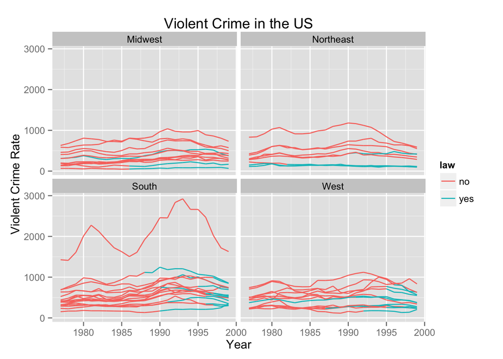

```r
ggplot(data=dat,mapping=aes(x=year,y=violent,group=state,color=law))+geom_line() + ggtitle("Violent Crime Rate")+facet_wrap(~region)+ggtitle("Violent Crime in the US")+xlab("Year") + ylab("Violent Crime Rate")
```

There is still a lot going on in this graph; however, we can make some initial observations regarding the data set. It seems that one southern state has a much higher violent crime rate than the others. By looking at the average rate over these years (below) we can see that this “state” is Washington D.C. As we are looking at a crime rate, I think the violence in the nation’s capital is blown a little out of proportion by the low population (also below) in the region. Also, although the data set does not have data comparing rural to urban areas, I believe crime rates are higher in urban regions. Washington D.C. is largely if not completely urban. This combined with the low total population leads to such a high rate.

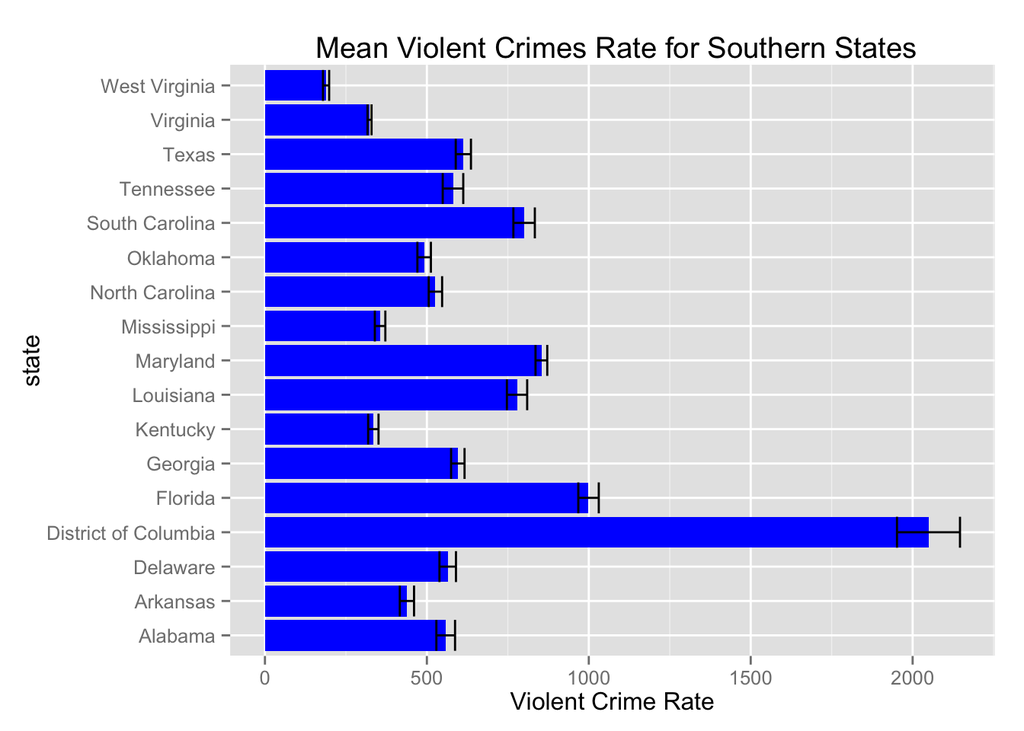

```r
se <- function(x) sqrt(var(x)/length(x)) #  standard error, I think it is appropriate to use this here

ave_crimes<- ddply(dat,~state,summarize,mean_vio=mean(violent),mean_murder=mean(murder),mean_rob=mean(robbery),mean_pop=mean(population),se_vio=se(violent),se_pop=se(population)) # Average the crime rates for each state, and get the standard error - we will only plot the violent crime rate

ave_crimes<-join(ave_crimes,cen.dat,by="state",type="left") # Add region data
south<-subset(ave_crimes,region=="South") # Restrict to Southern "states"

crime_lim<-aes(ymax=mean_vio+se_vio,ymin=mean_vio-se_vio) #limits for error bars
pop_lim<-aes(ymax=mean_pop+se_pop,ymin=mean_pop-se_pop)#limits for error bars
ggplot(south,mapping=aes(x=state,y=mean_vio))+geom_bar(stat="identity",fill="blue")+coord_flip()+ggtitle(" Mean Violent Crimes Rate for Southern States")+ylab("Violent Crime Rate")+geom_errorbar(crime_lim)
```

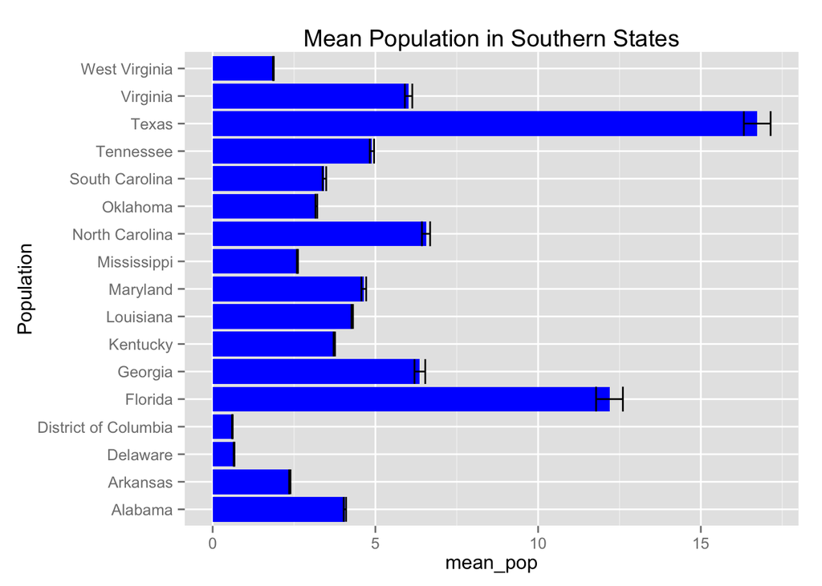

```r
ggplot(south,mapping=aes(x=state,y=mean_pop))+geom_bar(stat="identity",fill='blue')+coord_flip()+ggtitle("Mean Population in Southern States")+xlab("Population")+geom_errorbar(pop_lim)
```

The brief view of the data above also seems reveals that many states have changed their laws overtime to favor more lenient gun regulation. I will spend some time investigating this issue a little later.

### Does gun availability decrease crime?

This brings me to the heart of the data set, and the reason it was developed (as far as I can tell). Does gun availability decrease the number of violent crimes in state? Based on the title of the paper this data was originally used in, I think there is evidence in the data set to suggest that lenient gun laws do not discourage violent I just have to find it.

I will start with the hypothesis that guns do discourage violent crimes and set out to reject this hypothesis. As I hinted in the start of this report, we’ll be using a graphical approach and won’t actually be running a full statistical analysis.

### Are is there less crime in states with “shall issue” laws?

Taking a basic approach, all thing equal (which admittedly they probably are not) if “shall issue” laws decrease violent crimes that should be apparent in the violent crime rates in each of the cases across time.

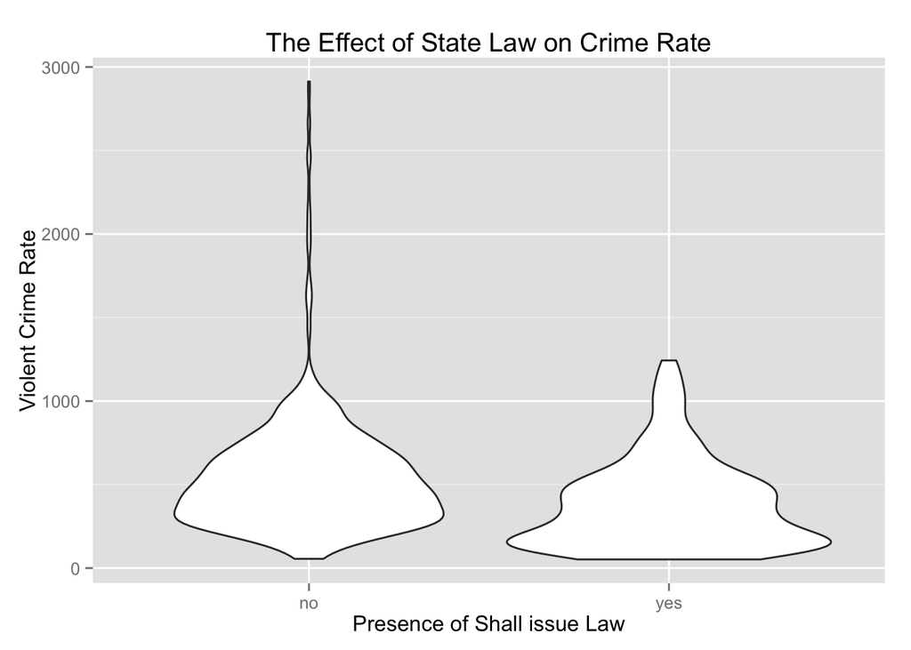

```r
ggplot(dat,mapping=aes(x=law,y=violent))+geom_violin()+ggtitle("The Effect of State Law on Crime Rate")+xlab("Presence of Shall issue Law")+ylab("Violent Crime Rate")
```

Looking at the distributions above it does seem that there is perhaps less crime in the presence of a “shall issue” law; however, if there is a difference, it is not substantial and warrants further investigation.

### Does the presence of “shall issue” laws affect the role population density has on violent crime rate?

The data suggest there is a positive correlation between population density and violent crime rates. Maybe “shall issue” laws decrease this correlation.

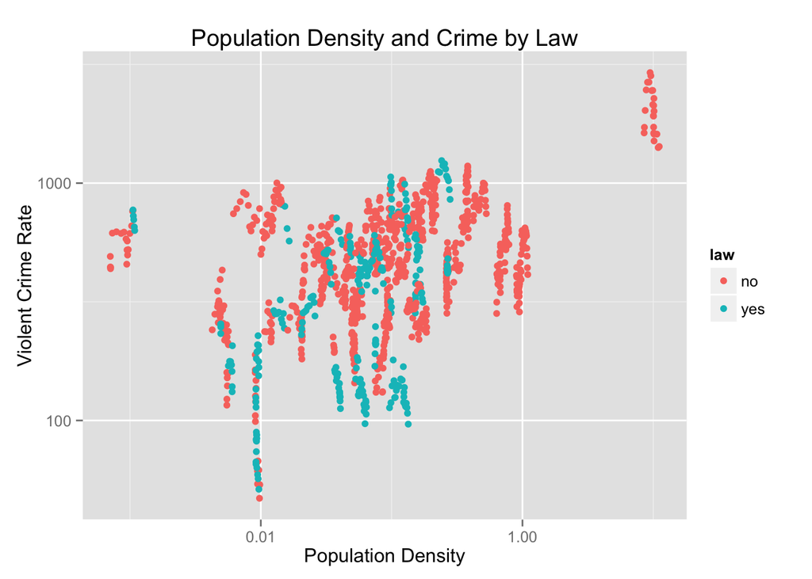

```r
ggplot(dat,mapping=aes(x=density,y=violent,color=law))+geom_point()+scale_y_log10()+scale_x_log10()+ylab("Violent Crime Rate")+xlab("Population Density")+ggtitle("Population Density and Crime by Law")
```

If population density is correlated with violent crime rate, and “shall issue” laws decrease this rate, we would expect the lower rates of crime in states with “shall issue” laws even when the population density of states is similar. From the graph above it is not readily apparent that this is the case. In fact the violent crime rates cluster more by state than by law status as shown below.

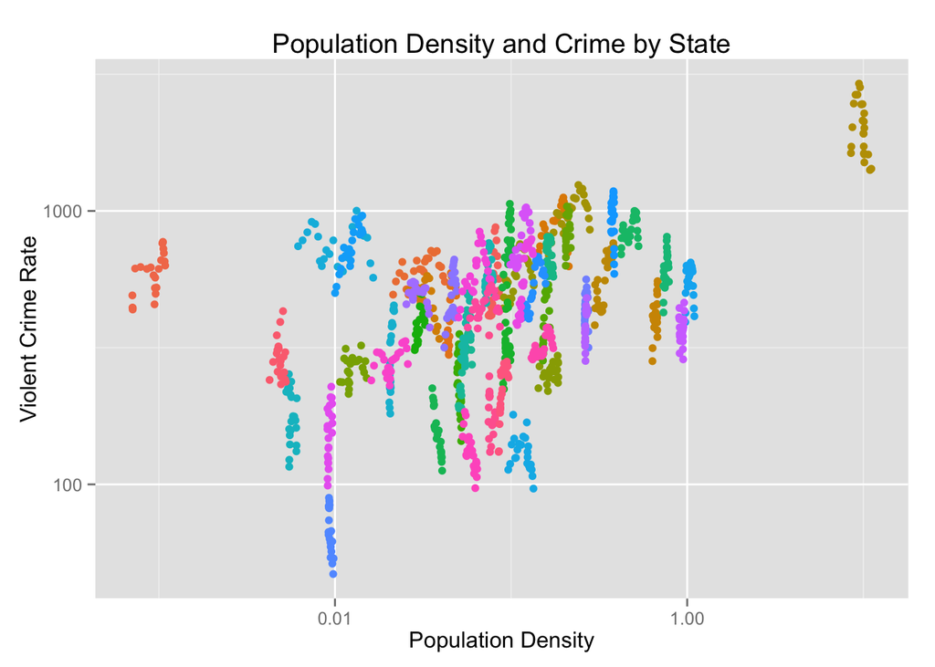

```r
ggplot(dat,mapping=aes(x=density,y=violent,color=state))+geom_point()+scale_y_log10()+scale_x_log10()+theme(legend.position="none")+ylab("Violent Crime Rate")+xlab("Population Density")+ggtitle("Population Density and Crime by State")
```

A look at the relationship between the other data metrics and violent crimes gives similar results, and doesn’t shed too much light on the question of gun laws and crime. This is most likely because crime is complex and the social variables which influence crime rates are varied. Perhaps if I stratified the data or controlled for these variables I could be more confident in testing the hypothesis that “shall issue” laws decrease violent crime rates, but that might be beyond the scope of this report, and certainly beyond my present understanding of gun issues.

### How has the popularity of shall issue laws changed over time?

First I will look at the country level and to see how the number of states with “shall issue” laws have increased over time, and possibly look to elucidate reasons behind shifts.

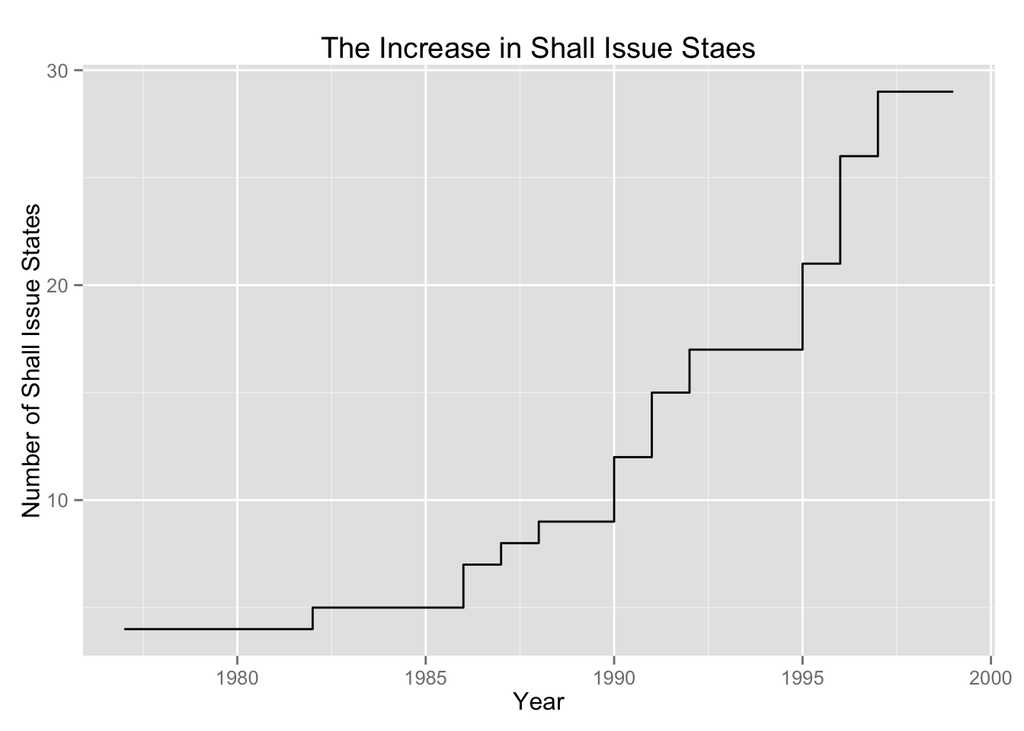

```r
yes_law<-ddply(dat,~year,summarize,easy_gun=length(which(law=="yes"))) # a data.frame with the number of yes states each year

ggplot(yes_law,mapping=aes(x=year,y=easy_gun))+geom_step()+ggtitle("The Increase in Shall Issue Staes")+xlab("Year")+ylab("Number of Shall Issue States")
```

We can see from this plot that the number of states with “shall issue” has drastically increased overtime with most of the growth after 1990. My hypothesis is that this rise was due to the belief that an increase in guns would lead to a decrease in crime, coupled with an increased crime rate. (Remember that I’m not a sociologist and I am just trying to follow my nose)

Looking at the average crime rates over the years we can see there was an increase in violent crimes, murder, and robbery in the years leading up to the 1990s.

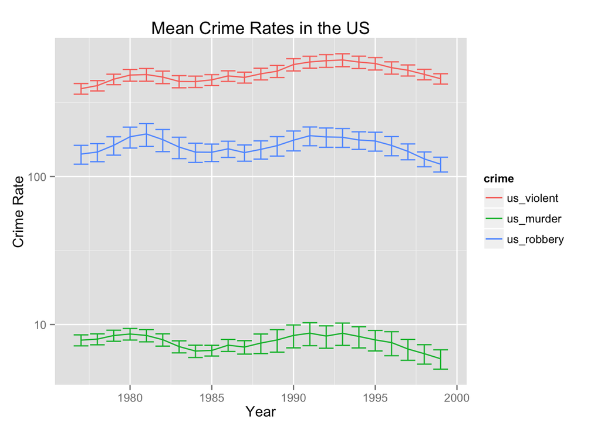

```r
us_rates<-ddply(dat,~year,summarize, us_violent=mean(violent),us_murder=mean(murder),us_robbery=mean(robbery)) # Average crime rates by year
us_rates<-melt(us_rates,id.vars="year",value.name="rate",variable.name="crime")# long form


us_se<-ddply(dat,~year,summarize, us_violent=se(violent),us_murder=se(murder),us_robbery=se(robbery))# se of crime rates by year
us_se<-melt(us_se,id.vars="year",value.name="se",variable.name="crime") #long form

mean_crimes<-join(us_rates,us_se,by=c("year","crime"),type="left") # merge forms
limits<-aes(ymax=rate+se,ymin=rate-se) # limits for error bars
ggplot(mean_crimes,mapping=aes(x=year,y=rate,group=crime,color=crime)) + geom_line()+scale_y_log10()+geom_errorbar(limits)+ggtitle("Mean Crime Rates in the US")+xlab("Year")+ylab("Crime Rate")
```

I think this rise in crime would only trigger a decrease in gun regulation if there was previous evidence suggesting that states with less stringent gun control have lower crime rates.

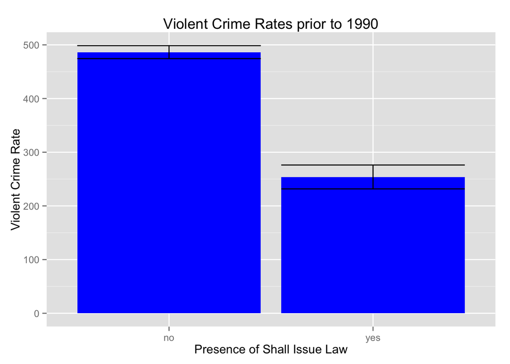

```r
older<-subset(dat,year<1990) # data set prior ot 1990
older<-ddply(older,~law, summarize, se_v=se(violent),se_m=se(murder),se_r=se(robbery),violent=mean(violent),murder=mean(murder),robbery=mean(robbery)) # mean and se of violence by law prior to 1990
limits<-aes(ymax=violent+se_v,ymin=violent-se_v)
ggplot(older,mapping=aes(x=law,y=violent))+geom_bar(stat="identity",fill="blue")+geom_errorbar(limits)+ggtitle("Violent Crime Rates prior to 1990")+xlab("Presence of Shall Issue Law")+ylab("Violent Crime Rate")
```

It seems plausible that the increase in gun leniency in 1990s was based on the increase in violent crime and the fact that data prior to 1990 lenient gun control policies are correlated with lower rates of violent crimes ( at least when visualized this way).

### Which states and regions adapted “shall issue” laws first and/or fastest?

Let’s look now and see which regions adapted laws

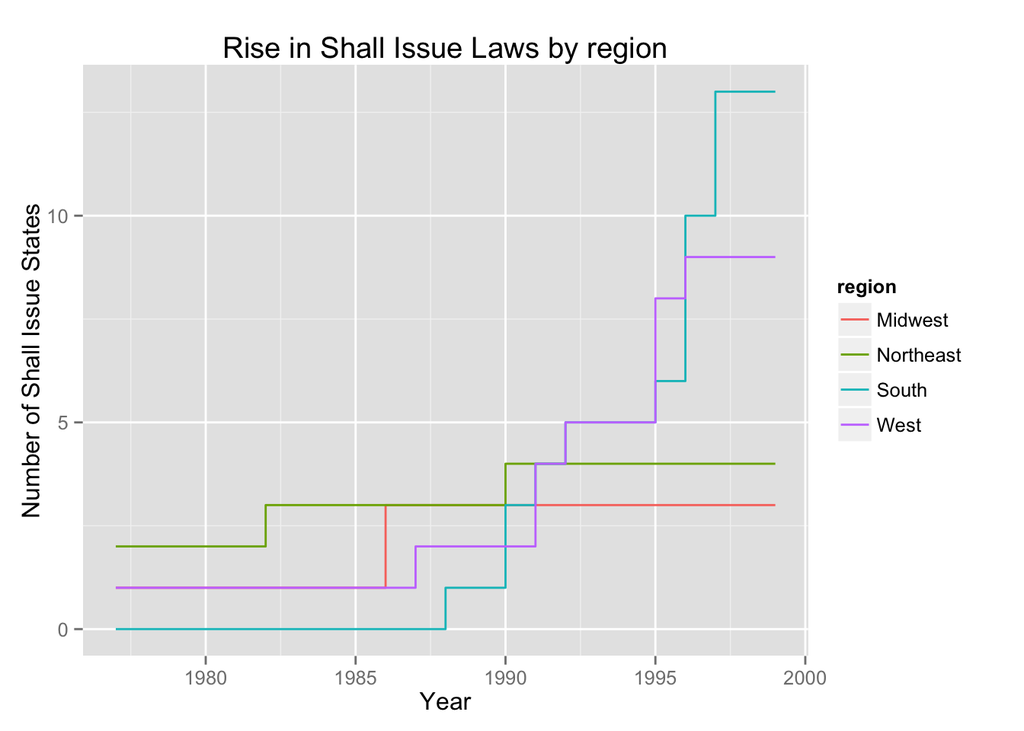

```r
yes_law_region<-ddply(dat,.(year,region),summarize,easy_gun=length(which(law=="yes"))) # # counting the number of "yes" states by year and region


ggplot(yes_law_region,mapping=aes(x=year,y=easy_gun,group=region,color=region))+geom_step()+ggtitle("Rise in Shall Issue Laws by region")+xlab("Year")+ylab("Number of Shall Issue States")
```

Interestingly, the Northeast began with the most “shall issue” states but only saw modest growth over the course of the study whereas the South began with no “shall issue” laws and saw huge expansion during the nineties. It would be interesting to see what was driving this growth in one part of the country that was absent in the others.

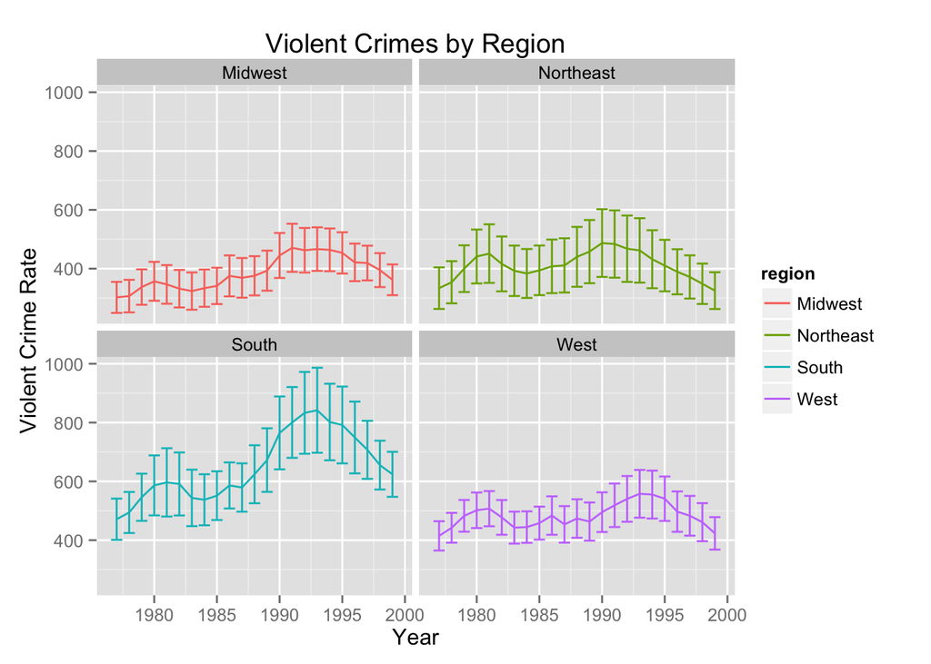

```r
region_rates<-ddply(dat,.(year,region),summarize, rate=mean(violent)) # Mean rates by year and reagion


region_se<-ddply(dat,.(year,region),summarize, se=se(violent)) # se of rates

region_crimes<-join(region_rates,region_se,by=c("year","region"),type="left")
limits<-aes(ymax=rate+se,ymin=rate-se)
ggplot(region_crimes,mapping=aes(x=year,y=rate,group=region,color=region)) + geom_line()+geom_errorbar(limits)+facet_wrap(~region)+ggtitle("Violent Crimes by Region")+xlab("Year")+ylab("Violent Crime Rate")
```

The South, which saw the most growth in “shall issue” laws, also saw the largest increase and decrease in violent crime rates. All regions saw this increase in the nineties which leads me to think that it is independent of “shall issue” law status. However, as I mentioned earlier it would be interesting to see if the belief that “shall issue” laws decrease violent crimes lead to such a rise in the laws in response to increases in crime. Perhaps even the converse is true that the increase in crime was driven by the “shall issue” laws. It would be interesting to read the original paper and get an idea as to what an in-depth analysis of this data would reveal.

This is a large data set that I was unable to summarize simply by skimming the raw data. I think I’ve begun to summarize some trends in the data and started to uncover some dynamics in “shall issue” laws and crime rates in different regions. There is more to do here, but I’d appreciate any input in other things to look at and/or ways to make the graphs more readable.